# Assignment week 2

Central limit theorem, CI’s, T-test

Author

Alejandro Molina-Moctezuma

# This lab

In this lab we are going to explore the following:

1. Plotting and using ggplot. I commonly use ggplot, although still use “baseR” quite often to plot. But the reality is that the ggplot package **is probably the best tool and package to plot in R.** We will learn to make plots using ggplot and we will use it throughout the course.
2. Data simulation. Baby steps on how to simulate data.
3. The central theorem and confidence intervals: hopefully this exercise will have you understand this, and never forget it
4. Linear models and t-test

This is a “longer” assignment. But the next one will be shorter. You can take as long as you need on it 😃

You can download the quarto document and use it to answer the questions, copy code, modify code, etc.

# Remember!

**Note**

If you are comfortable with R basics, you can write the code for this exercise directly into Quarto. To add extra code chunks, write this symbols: ```{r}, if you are still not comfortable with R, I recommend for the time being you open a new file and copy and paste the code there, and run it. You can submit this as a qmd file or as an r-script. Whatever you feel more comfortable with at the moment (.qmd + .html preferred)

You can also go to insert > executable cell > R and that should insert an r chunk

**Why is my data not loading?**

Make sure you download the data file, and also save the quarto file you’re working on in the same folder. I recommend you create a project

# The Central Limit Theorem and confidence intervals

The applet on [Ward and Nolte’s book](https://collinn.github.io/sbi/ch7.html#central-limit-theorem) is a great example of the central limit theorem. If you still have questions about this topic I recommend you check the applet on section 6.3 and the one on section 7.2.

We are going to do a little experiment regarding the Central Limit Theorem and confidence intervals. We are going to:

This may seem like a lot… but it is not! It can be done fairly easily using R. And at this point I will still guide you step by step.

**If you feel like you are falling behind**

I cannot stress this enough. If you feel like you are falling behind, I can meet you MWF before or after class, or you can meet with me in my office to go over coding, any topic, or any issues you may be having.

Let start

#### Step 1: Simulate your data

This may be the most complicated step. We haven’t really talked about distributions, and you’re not expected to know this at this point. If you are not comfortable simulating your own data, I am providing some examples below. Choose the one you like the most, and use it to simulate your data. If you decide to use one of the provided examples, then you can skip this, and go directly to the Section 3.0.0.2 section. If you want to simulate your own population, look at the examples.

**Warning**

Be careful! This data is simulated, so each time you run the code it will generate a new set of data. Make sure to simulate your population only once!

If you want to simulate the example, let’s do the following:

1. Decide what system you are trying to simulate
2. Create an object called “data” in which you will simulate 10,000 datapoints generating 10,000 random deviate using the distribution of your choice
3. Obtain the population parameters (mean and sd). Call them mu and sd.

#### Examples

I have different examples. In order to simulate the data, simply run the example that you want. Only run one example (the one you want) or they will overwrite themselves. These have different distributions

Please be aware that I am not super knowledgeable about these systems, so the units may be completely off. I tried my best though!

##### Example 1: bats 🦇

This data-set is on the wing aspect ratio of the pygmy round-eared bat.

```r
data<-rnorm(10000, mean = 5.5, sd=0.75) #your population, 10,000 individuals total
mu<-mean(data) #real population parameter
sigma<-sd(data)
```

##### Example 2: frogs 🐸

This data-set is on the presence-absence data of Chytridiomycosis in a population of [*Lithobates clamitans*](https://en.wikipedia.org/wiki/Lithobates_clamitans)This is a binomial distribution. 1 is presence and 0 is absence

```r
data<-rbinom(1000,1,0.23) #your population, 10,000 individuals tota.
mu<-mean(data) #real population parameter
sigma<-sd(data)
```

##### Example 3: grapes 🍇

This dataset is on the number of wild grapes in 10,000 vines in a meadow (you can also make this wine grapes in a vineyard if you are into that).

```r
data<-rpois(1000,40) #your population, 10,000 individuals total.
mu<-mean(data) #real population parameter
sigma<-sd(data)
```

##### Example 4: Beef 🐮

Annual live weight (LW) meat production in 10,000 hectares (n = 10,000), each hectare represents one datapoint.

```r
data<-rnorm(10000, mean = 410.5, sd=60) #your population, 10,000 individuals total
mu<-mean(data) #real population parameter
sigma<-sd(data)
```

**✏️ Question 1 ✏️**

Come up with some potential systems/examples that I can simulate or use for future students. Coming up with examples is probably the most challenging aspect of teaching this course! You don’t have to come up with actual numbers. Just ideas!

#### Step 2: Take a sample

Before taking a sample, write down or make a mental note of the real population mean:

```r
mu
```

```
[1] 409.568
```

We are going to simulate taking a sample of size 40. It is actually pretty straightforward to take a sample:

```r
n<-40
sample1<-sample(data,n)
sample1_mean<-mean(sample1)
s<-sd(sample1)
```

Now, let’s calculate the standard error. Remember, SE is:

$$SE = \frac{s}{\sqrt{n}}$$

Complete the code to estimate SE:

```r
SE1<-s/sqrt(n)
```

If you remember the class, we said that usually to estimate confidence intervals we use the following equation:

$$LowerCI = \overline{y} - 1.96SE$$
$$UpperCI = \overline{y} + 1.96SE$$

But why? Look at the following plot:

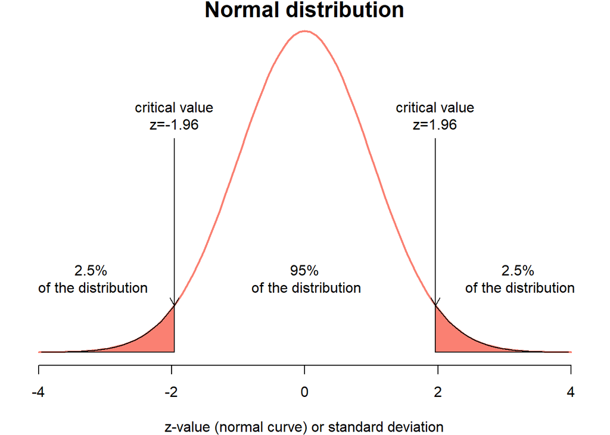

So, our confidence interval is called a 95% confidence interval, and has an $\alpha = 0.05$ (think of this as a 5% chance of the parameter not included within the confidence interval). We can actually use any CI value we want, but 95% is usually used. It is OK to use a critical value of 2 or one of 1.96

We can also estimate the critical values for any alpha we want. For this, we use the following code:

```r
qnorm(0.025) #for lower CI
```

```
[1] -1.959964
```

```r
qnorm(0.975) #for highert CI
```

```
[1] 1.959964
```

##### Assignment question 2:

**✏️ Question 2 ✏️**

See the last code chunk, and answer: Why do we use 0.025 and 0.975 instead of 0.95? If you can’t figure it out, that’s ok, but we should meet at some point so I can explain it 😃.

We can also use the critical value (in this case $\alpha=0.05$) to find our critical values with the following function:

```r
alpha<-0.05
qnorm(alpha/2)
```

```
[1] -1.959964
```

```r
qnorm(1-alpha/2)
```

```
[1] 1.959964
```

Try a different critical value.

Also, while I am estimating the critical values for both lower and upper CI’s, you only need to do one because they are symmetric. We also will very rarely use the normal distribution and will be using a different distribution called “t distribution”, and can estimate the critical values using `qt()`. But for now, lets stick to the normal distribution.

Ok, let’s go back to our sample:

We can estimate the CI’s now, and check whether the real parameter mean is included within them. Remember, you estimated the real mean and named it mu:

The following code is used to estimate confidence intervals.

```r
UCI1<-sample1_mean+1.96*SE1
LCI1<-sample1_mean-1.96*SE1
```

And you can use the following code to check whether the real mean (mu) is included within the confidence intervals you estimated!

```r
if(mu<UCI1 & mu> LCI1){
  print(paste0("Nice! The real parameter ", mu, " is included within the confidence interval. LCI: ", LCI1," UCI: ", UCI1))
} else {print(paste0("Bummer! The real parameter ", mu, " is NOT included within the confidence interval. LCI: ", LCI1," UCI: ", UCI1))}
```

```
[1] "Nice! The real parameter 409.567954035342 is included within the confidence interval. LCI: 383.441574095474 UCI: 419.755019786839"
```

In class I mentioned examples in which I would sample the same population multiple times. Let’s do that, let’s start by taking a second sample and estimating the confidence interval:

```r
sample2<-sample(data,n)
sample2_mean<-mean(sample2)
s2<-sd(sample2)

SE2<-s2/sqrt(n)

UCI2<-sample2_mean+1.96*SE2
LCI2<-sample2_mean-1.96*SE2
if(mu<UCI2 & mu> LCI2){
  print(paste0("Nice! The real parameter ", mu, " is included within the confidence interval. LCI: ", LCI2," UCI: ", UCI2))
} else {print(paste0("Bummer! The real parameter ", mu, " is NOT included within the confidence interval. LCI: ", LCI2," UCI: ", UCI2))}
```

```
[1] "Nice! The real parameter 409.567954035342 is included within the confidence interval. LCI: 387.247763982706 UCI: 419.193073235633"
```

Run the code again for sample 3

Now, I want you to do this 100 times (take a sample, estimate the CI, check if the real mean is included). This is just like in the applet from the book you read this week..

This might seem like a lot of work, but we can use a thing called `for loops`. Keep reading! 😃

A `for` loop allows us to iterate over a sequence. For example:

```r
for (x in 1:5){
  print(x*2)
}
```

```
[1] 2
[1] 4
[1] 6
[1] 8
[1] 10
```

Some important aspects of that last for loop:

$$\underbrace{for}_{initiate\; loop}\underbrace{(x\; in\; 1:5)}_{vector} \underbrace{print(x*2)}_{code\; block}$$

1. You start the for loop using `for`
2. You give a vector of values. During the `for` loop, x will take the first value in the vector and run the code block. After this, x will take the second value and run the code block. It will continue doing this until it reaches the last value. This is the “last iteration”. After the last iteration, it will exit the for loop.

Let’s use a `for` loop to take100 samples.

First, let’s create some empty vectors to store our results. I like to create vectors before running the `for` loop because it is computationally faster than concatenating results as the loop goes. We will create vectors of size 100:

```r
experiment<-1:100
means<-rep(NA,100) #For the means
s<-rep(NA,100) #sd
SE<-rep(NA,100) #SE
LCI<-rep(NA,100) # Lower CI
UCI<-rep(NA,100) # Upper CI
inclusive<-rep(NA,100) #is the real parameter included?
alpha<-0.05 #our alpha
lower<-qnorm(alpha/2) #lower critical value
upper<-qnorm(1-alpha/2) #upper critical value
```

We can now run the code:

```r
for(i in 1:100){
sample<-sample(data,n)
means[i]<-mean(sample)
s[i]<-sd(sample)
SE[i]<-s[i]/sqrt(n)
LCI[i]<-means[i]+SE[i]*lower
UCI[i]<-means[i]+SE[i]*upper
if(mu<UCI[i] & mu> LCI[i]){
  inclusive[i]<-T} else{
    inclusive[i]<-F
  }
}
```

That is pretty cool. You can run for loops with thousands of iterations and it will run in seconds!

We would expect that about 95 of our runs had the real parameter included within the estimated CI’s. There is a super easy way to estimate this:

```r
sum(inclusive)
```

```
[1] 93
```

That’s it! It will give you the number of “successes”.

At the end of the document, I have mroe information on for loops, and a “challenge” if you want to create one.

Let’s create a dataframe in which we store all of these results.

```r
df<-data.frame(experiment,means,s,SE,LCI,UCI,inclusive)
```

Now, let’s plot it. We will use `ggplot`. `ggplot` is a package, and packages need to be installed before you are able to use them. Similar to computer software, you **only need to install a package once in a computer**. Let’s install `ggplot` (if you already have ggplot installed, you can skip this step

```r
install.packages("ggplot2")
```

After you have installed a package, you need to load it before using it using the `library` command. Again, think of this as any software in your laptop. After you install it, you need to open the program before you run it:

```r
library(ggplot2)
```

This is how ggplot works:

$$\underbrace{ggplot}_{initiate\; plot}(\underbrace{data = df}_{data\;frame},\; \underbrace{aes(x =\; , y = \;)}_{plot\; attributes}) + \underbrace{geom\_line()}_{geometry\:line} + \underbrace{geom\_point()}_{geometry\:point} + \underbrace{theme()}_{customize}$$

In that example we have two geometries: lines and points. So, in that case we would be plotting lines and points (easy, right?). If you want to see all the available geometries, visit: https://ggplot2.tidyverse.org/reference#geoms

We will use ggplot to plot all of the points:

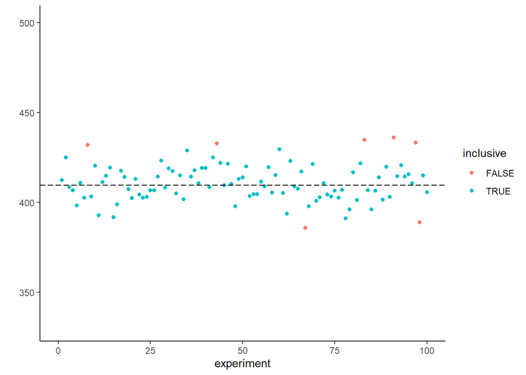

```r
ggplot(df, aes(x = experiment, y = means,colour=inclusive)) +
   geom_point() +
   geom_hline(yintercept = mu, color = "black", linetype = "longdash") +
   scale_y_continuous(name = "", limits = c(min(df$LCI) - min(df$LCI)/10 , max(df$UCI + max(df$UCI)/10))) +
   scale_x_continuous(limits = c(0, 100)) +
   theme_classic()
```

Three things you may be thinking about this plot:

1. Plotting it seems harder than I made it seem! There are more lines there
2. It’s a lot of code, and I’m not sure how good it looks
3. It’s missing the confidence intervals!

I agree with all of that. However, as class goes by I hope you will understand all the sections of the plot and make nicer plots than this!

For the time being, let’s inspect each element:

1. `ggplot(df, aes(x = experiment, y = means,colour=inclusive))` initiate the plot, provides the data, and provides values for x, y, and for the color
2. `geom_point` draws the geometry (point) with our provided elements
3. `geom_hline` is drawing a horizontal line. We need to provide an actual value (mu in this case). Therefore it represents the real parameter
4. `scale_y_continuous` and `scale_x_continuous` provide information for the axes. You won’t use this 99% of the time, and no need to worry about it right now. In this case I created y axis to be able to easily add the confidence intervlas in one of the following steps.
5. `theme_classic` is providing a theme. Try running it without a pre-defined theme. I don’t like the ggplot standard theme

Finally, please notice how we add elements using `+`.

Now, I don’t like the colors of the dots. I am going to change them:

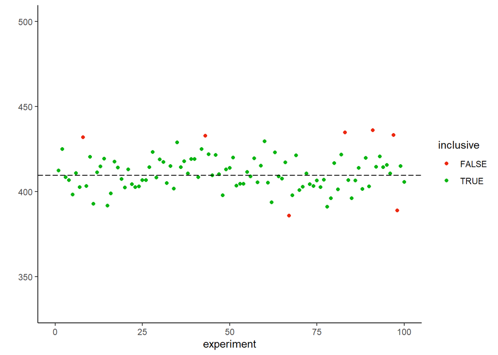

```r
ggplot(df, aes(x = experiment, y = means,colour=inclusive)) +
   geom_point() +
   geom_hline(yintercept = mu, color = "black", linetype = "longdash") +
   scale_y_continuous(name = "", limits = c(min(df$LCI) - min(df$LCI)/10 , max(df$UCI + max(df$UCI)/10))) +
   scale_x_continuous(limits = c(0, 100)) +
   theme_classic()+
  scale_color_manual(values=c("#ec280e", "#06b512"))
```

I like those colors better. There are many ways to choose colors, but I like giving R the HEX code of the color I want. I usually use a color picker: https://htmlcolorcodes.com/color-picker/ to pick the color, and that supplies me with the HEX code.

**✏️Question 3 ✏️**

Change the plot colors

Finally, I want to add the CI’s:

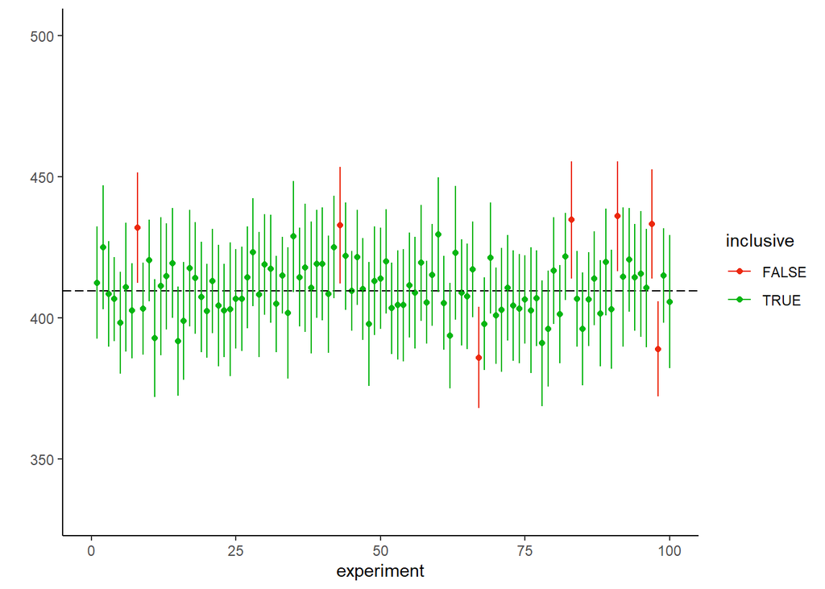

```r
ggplot(df, aes(x = experiment, y = means,colour=inclusive,ymin = LCI, ymax=UCI)) +
   geom_point() +
   geom_hline(yintercept = mu, color = "black", linetype = "longdash") +
   scale_y_continuous(name = "", limits = c(min(df$LCI) - min(df$LCI)/10 , max(df$UCI + max(df$UCI)/10))) +
   scale_x_continuous(limits = c(0, 100)) +
   theme_classic()+
  scale_color_manual(values=c("#ec280e", "#06b512"))+
  geom_errorbar(width = 0)
```

Notice how I added `ymin` and `ymax` to `aes()`? I am providing more plot attributes. I also added `geom_errorbar(width = 0)`.

# One sample T-test

Finally! We will work on a one-sample t-test.

Example: The Jackson Laboratory (Bar Harbor, ME) shipped you some lab mice 🐁 from the C57BL/6J strain. You chose this specific strain because their mean mass at 21 weeks is 20.2 grams, which is important for your experiments. However, you suspect your mice set might have a different weight, so, you take a random sample of 21 individuals to check.

Download the “mousedata.csv” file and load it in an object named mousedata and inspect it

```r
mousedata<-read.csv("mousedata.csv")
mousedata<-mousedata$x
mousedata
```

```
 [1] 18.41489 17.96535 20.23447 16.91896 19.21828 25.28136 17.35877 18.97449
 [9] 21.58163 16.26229 18.40497 20.59939 19.41167 20.00668 18.53189 17.06733
[17] 19.18580 22.53532 21.62798 20.19551 19.47198
```

Let’s plot the data:

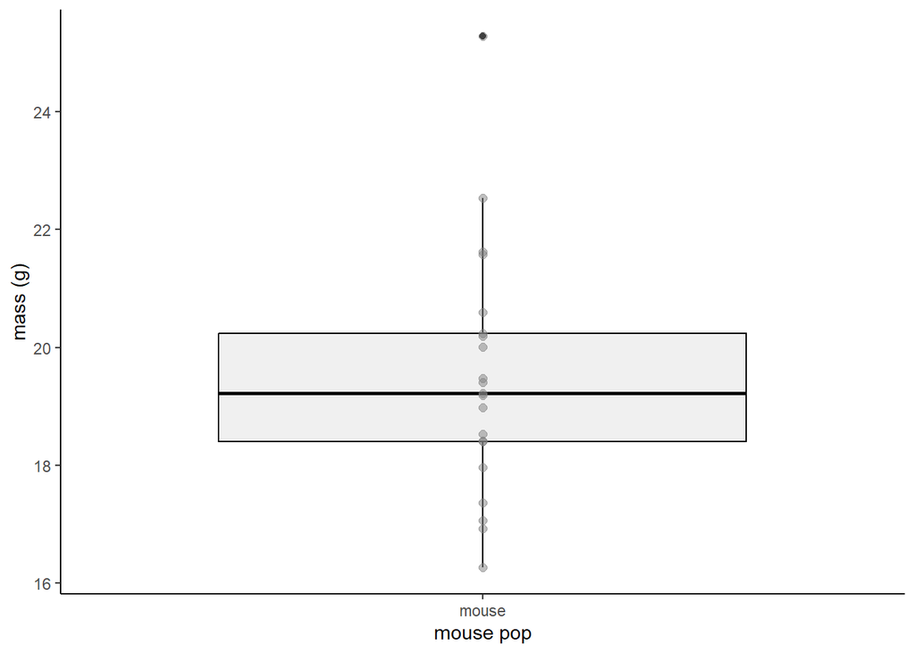

```r
df1<-data.frame(mousedata,mouse="mouse")
ggplot(data=df1,aes(x=mouse,y=mousedata))+
  geom_boxplot(fill=gray(0.7,0.2),color="black")+
  geom_point(size=2,col=gray(0.5,0.5))+
   theme_bw() + theme(panel.border = element_blank(), panel.grid.major = element_blank(),
                     panel.grid.minor = element_blank(), axis.line = element_line(colour = "black"))+
  ylab("mass (g)")+
  xlab("mouse pop")
```

Not a very good looking plot. And we are not comparing groups, so, a bit pointless. But you will be plotting the next example. It also brings an important issue:

Boxplot is probably the most commonly used chart type to compare distribution of several groups. However, you should keep in mind that in a boxplot data distribution is hidden behind each box. For instance, a normal distribution could look exactly the same as a bimodal distribution. Please consider a violin plot or a ridgline chart instead. For reference, here is how to do a violin plot:

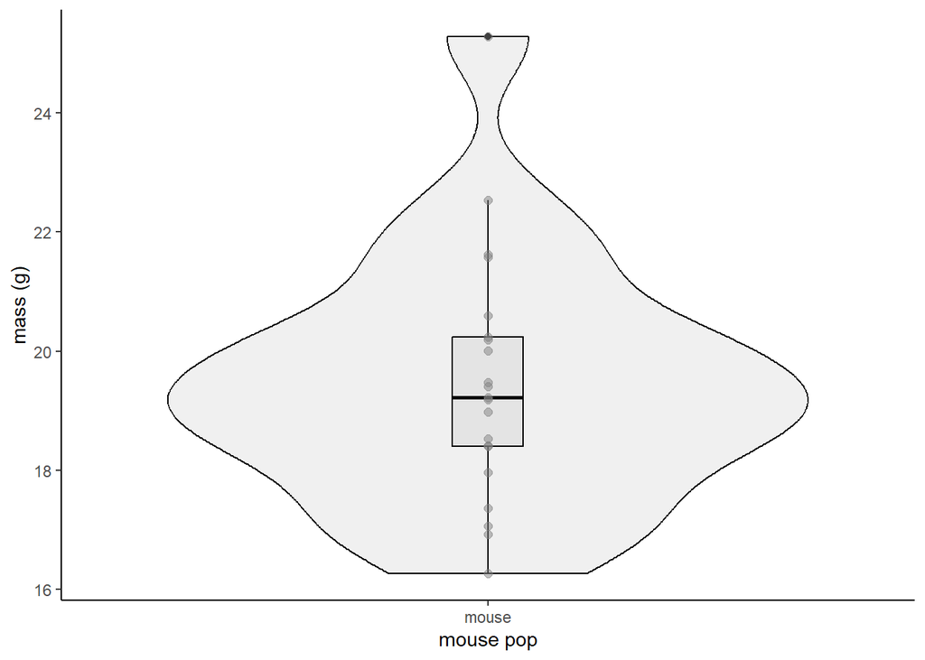

```r
df1<-data.frame(mousedata,mouse="mouse")
ggplot(data=df1,aes(x=mouse,y=mousedata))+
  geom_violin(fill=gray(0.7,0.2),color="black")+
  geom_boxplot(fill=gray(0.7,0.2),color="black",width=0.1)+
  geom_point(size=2,col=gray(0.5,0.5))+
   theme_bw() + theme(panel.border = element_blank(), panel.grid.major = element_blank(),
                     panel.grid.minor = element_blank(), axis.line = element_line(colour = "black"))+
  ylab("mass (g)")+
  xlab("mouse pop")
```

After plotting, the question is: is the average mass of your mice equal to 20.2 grams?

The relevant hypotheses would be:

- $$Ho : \mu_1 = 20.2$$
- $$Ha : \mu_1 \neq 20.2$$

Hopefully you understand this based on the readings, and some previous stats classes. If it’s not clear, talk to me.

We will also estimate a “critical value” that corresponds to an $\alpha$ of 0.05. While now we can estimate p directly with r, you may remember your stats courses where you were tasked with finding a critical value, in order to decide whether to reject or fail to reject the null hypothesis.

We cannot use 1.96 because our sample is small (and we are doing a t-test). Therefore, estimating a critical value from t distribution is better.

We will use the following code to obtain our critical value:

```r
alpha<-0.05
qt(c(alpha/2, 1-alpha/2), df=21-1)
```

```
[1] -2.085963  2.085963
```

Our degrees of freedom are n-1. And our critical values are -2.08 and 2.08. Any value lower than -2.08 or higher than 2.08 will be significant (i.e., we reject the null hypothesis)

**🧠Think about it 🧠**

Why are degrees of freedom n-1?

Essentially, our critical values show the following:

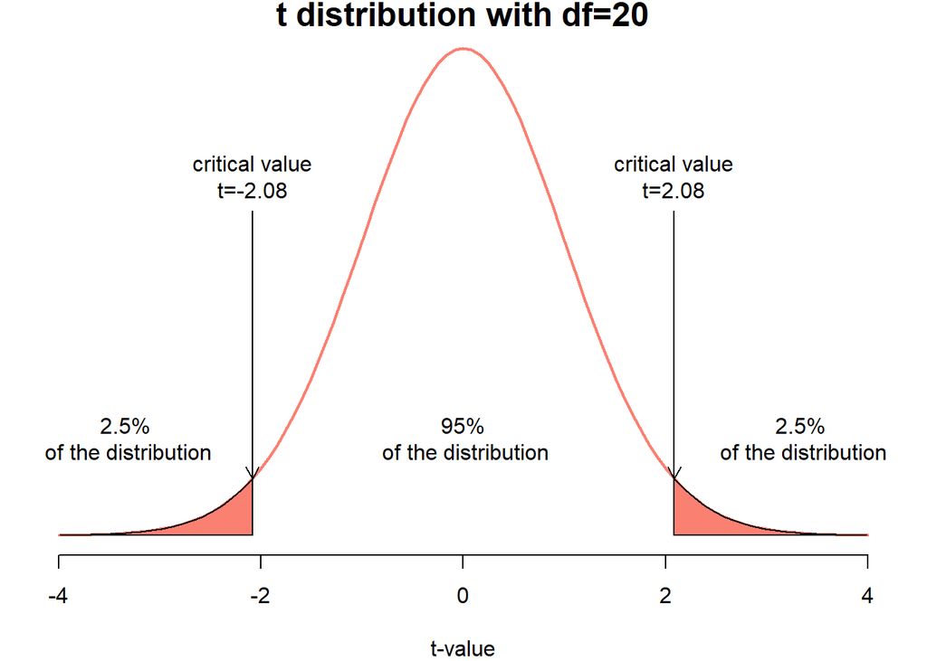

This is the t-distribution for our example.

If you are curious as to what happens to the t distribution as df goes up, try calculatin it for 10,000 df. It actually becomes 1.96 and is no different than a normal distribution.

Now, let’s solve our problem. Remember, our linear model looks like:

$$y_i = \beta_0 + \epsilon_i \ \ \ \ \ \text{where} \ \ \ \ \ \epsilon_i \sim \text{N}(0,\sigma)$$